# Контрольная работа 1

Three distinct cell populations express extracellular matrix proteins and increase in number during skeletal muscle fibrosis

Михаил Папков

8 апреля 2017 г

```r
library(DESeq2)
library(ggplot2)
library(clusterProfiler)
library(org.Hs.eg.db)
library(pheatmap)
library(dplyr)
library(VennDiagram)
library(amap)
library(dbscan)
options(width=120)
```

# Описание и подготовка данных

Предложен датасет RNA-seq 2017 года из статьи ”Three distinct cell populations express extracellular matrix proteins and increase in number during skeletal muscle fibrosis”. Статья о том, что важно понимать какие клетки производят компоненты внеклеточного матрикса; в поперечнополосатой мышце нахождение таких клеток важно в контексте заболеваний, где изменения внеклеточного матрикса могут вызывать фиброз и последующую повышенную жесткость тканей и их дисфункцию. Примечательного в статье то, что ребята сначала нашли те клетки, которые производят компоненты внеклеточного матрикса, а затем научились эти клетки изолировать и показали, что их три разных подтипа: fibroblasts (FB), fibro / adipogenic progenitors (FAP), skeletal muscle progenitor (SMP). После чего они взяли два вида мышей: the nesprin-desmin double knockout (DKO) mouse и wild-type (WT) mouse, отсортировали из них эти клетки и сделали RNA-seq.

Описание этих образцов находится в файле GSE89633_conditions.tsv, а сами данные экспрессии после выравнивания ридов на индексный геном находятся в файле GSE89633_counts.tsv

Прочитаем файлы:

```r
counts <- read.csv("../data/GSE89633_counts.tsv", sep = "\t", row.names = 1)
conditions <- read.csv("../data/GSE89633_conditions.tsv", sep = "\t", row.names = 1)

print(counts[1:6, 1:2])
```

```
##           Sample_B.bam Sample_BB.bam
## 100009600           33            14
## 100009609            0             0
## 100009614            0             0
## 100009664            0             0
## 100012               0             0
## 100017             195           323
```

```r
dim(counts)
```

```
## [1] 24393    20
```

```r
head(conditions)
```

```
##                        cells     conditions
## Sample_B.bam  cell type: FAP condition: DKO
## Sample_BB.bam cell type: FAP  condition: WT
## Sample_D.bam   cell type: FB condition: DKO
## Sample_DD.bam  cell type: FB  condition: WT
## Sample_F.bam  cell type: FAP condition: DKO
## Sample_FF.bam cell type: FAP  condition: WT
```

```r
dim(conditions)
```

```
## [1] 20  2
```

### DESeq2

DESeq2 – это царь-библиотека необходимая для работы с данными RNA-seq. Тут и дифференциальная экспрессия, и нормализации, и PCA-plots.

Подготовим dds для всех данных

```r
dds <- DESeqDataSetFromMatrix(countData = counts,
                              colData = conditions,
                              design = ~ cells + conditions)
dds <- dds[rowSums(counts(dds)) > 20, ]
dds <- DESeq(dds)
vst_dds <- vst(dds)
counts.norm <- assay(vst_dds)
```

# Исследование

## 1. Visual quality control and self-consistance

### 1.1 PCA

Строим PCA-plot на всех генах датасета

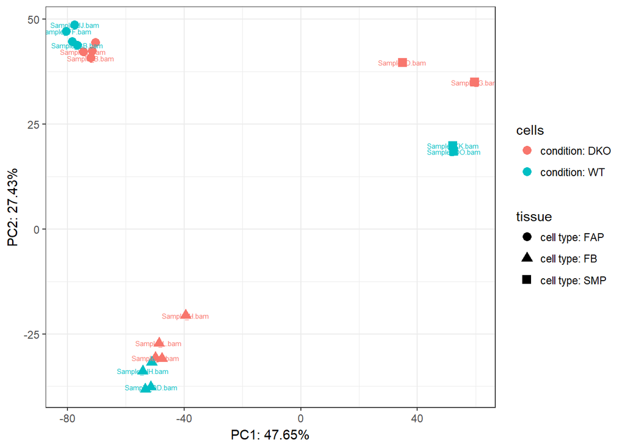

```r
pca_data <- prcomp(t(counts.norm))
percents <- pca_data$sdev^2 / sum(pca_data$sdev^2)
to_plot <- t(counts.norm) %*% pca_data$rotation

gdata <- data.frame(
  x=to_plot[, 1],
  y=to_plot[, 2],
  tissue=conditions[, 1],
  cells=conditions[, 2],
  name=rownames(conditions)
)

ggplot(data=gdata, aes(x=x, y=y, color=cells, shape=tissue, label=name)) +
  geom_point(size=3) + theme_bw()  +
  xlab(paste0("PC", 1, ": ", formatC(100 * percents[1], digits=4), "%")) +
  ylab(paste0("PC", 2, ": ", formatC(100 * percents[2], digits=4), "%")) +
  geom_text(size=2, check_overlap = T, position = position_jitter())
```

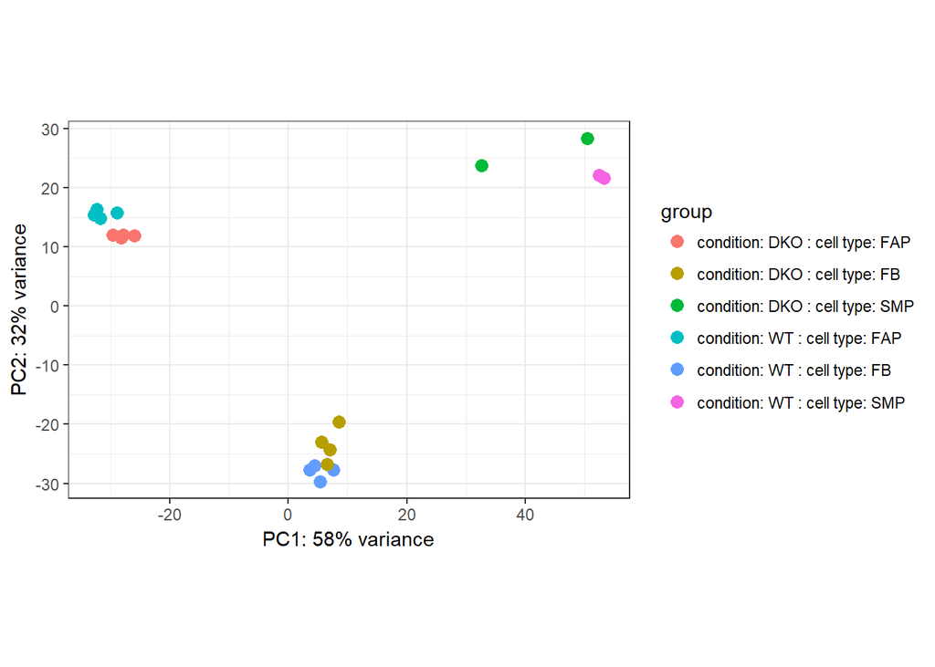

```r
plotPCA(vst_dds, intgroup=c("conditions", "cells")) + theme_bw()
```

### 1.2 Кластеризация

Взять 8000 самых экспрессированных генов (по средней экспрессии во всех сэмплах), кластеризовать эти гены используя функцию Kmeans из пакета amap (возьмите число кластеров, которое вам нравится от 8 до 12), и построить heatmap, как в домашней работе по кластеризации.

```r
dds_8000 <- dds[order(rowSums(counts(dds)), decreasing = T), ][1:8000, ]
dds_8000 <- DESeq(dds_8000)
vst_dds_8000 <- vst(dds_8000)
counts.norm_8000 <- assay(vst_dds_8000)
```

Используем rlog(dds) для получения логарифмированных значений экспрессии

```r
log_dds_8000 <- rlog(dds_8000)
counts.log_8000 <- assay(log_dds_8000)
```

Используем функцию Kmeans из пакета amap с методом “correlation”, c количеством кластеров равным от 8 до 12, и максимальным количеством итераций равным 20000

```r
kms <- Kmeans(counts.log_8000, method = "correlation", iter.max = 20000, centers = 8)
```

После этого вы можете достать соотвествие каждого гена кластеру с помощью элемента листа с названием “cluster”

```r
head(kms$cluster)
```

```
## 227753  12843  22190  12842  13179  12825
##      7      8      3      8      5      7
```

После этого от вас потребуется эту кластеризацию изобразить на хитмапе: гены должны быть отсортированы по кластерам, а столбцы сначала по клеткам, а затем по тканям.

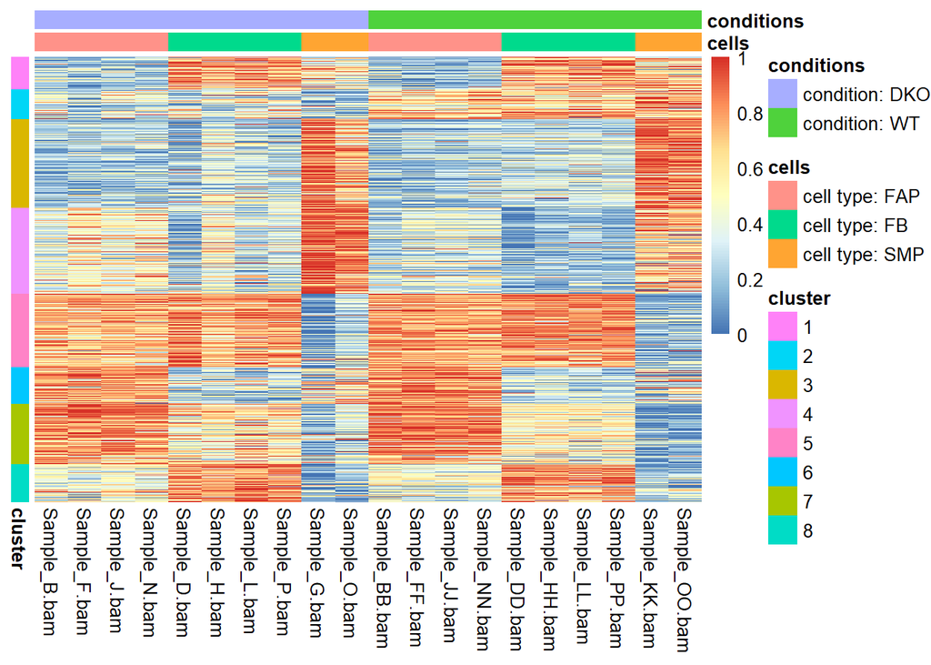

```r
to_visualise <- counts.log_8000[order(kms$cluster), order(conditions$conditions, conditions$cells)]
to_visualise <- t(apply(to_visualise, 1, function(r) {
  (r - min(r)) / (max(r) - min(r))
}))

pheatmap(to_visualise,
         show_rownames = F, cluster_rows = F,
         cluster_cols=F,
         annotation_col = conditions,
         annotation_row = data.frame(cluster = as.factor(kms$cluster)))
```

**Q: Можем ли мы судя по PCA plot и heatmap сказать, что в этом датасете есть явные аутлаеры?**

A: Явных аутлаеров не видно

**Q: Можем ли мы предположить по PCA plot, чем объяснена большая часть вариации в наших данных?**

A: Кажется, что наибольшая часть вариации объясняется типом клеток

## 2. Differential expression

Поделим данные на 3 группы сравнения: 1. FB WT vs FB DKO 2. FAP WT vs FAP DKO 3. SMP WT vs SMP DKO

```r
conditions_fb <- conditions[conditions$cells == "cell type: FB", ]
conditions_fap <- conditions[conditions$cells == "cell type: FAP", ]
conditions_smp <- conditions[conditions$cells == "cell type: SMP", ]

counts_fb <- counts[colnames(counts) %in% rownames(conditions_fb)]
counts_fap <- counts[colnames(counts) %in% rownames(conditions_fap)]
counts_smp <- counts[colnames(counts) %in% rownames(conditions_smp)]
```

Для каждой группы подготовим dds

```r
dds_fb <- DESeqDataSetFromMatrix(countData = counts_fb,
                              colData = conditions_fb,
                              design = ~ conditions)
dds_fb <- dds_fb[rowSums(counts(dds_fb)) > 20, ]
dds_fb <- DESeq(dds_fb)
vst_dds_fb <- vst(dds_fb)
counts.norm_fb <- assay(vst_dds_fb)

dds_fap <- DESeqDataSetFromMatrix(countData = counts_fap,
                              colData = conditions_fap,
                              design = ~ conditions)
dds_fap <- dds_fap[rowSums(counts(dds_fap)) > 20, ]
dds_fap <- DESeq(dds_fap)
vst_dds_fap <- vst(dds_fap)
counts.norm_fap <- assay(vst_dds_fap)

dds_smp <- DESeqDataSetFromMatrix(countData = counts_smp,
                              colData = conditions_smp,
                              design = ~ conditions)
dds_smp <- dds_smp[rowSums(counts(dds_smp)) > 20, ]
dds_smp <- DESeq(dds_smp)
vst_dds_smp <- vst(dds_smp)
counts.norm_smp <- assay(vst_dds_smp)
```

Получим данные дифференциальной экспрессии

```r
res_fb <- results(dds_fb)
mcols(res_fb)$description
```

```
## [1] "mean of normalized counts for all samples"
## [2] "log2 fold change (MAP): conditions condition: WT vs condition: DKO"
## [3] "standard error: conditions condition: WT vs condition: DKO"
## [4] "Wald statistic: conditions condition: WT vs condition: DKO"
## [5] "Wald test p-value: conditions condition: WT vs condition: DKO"
## [6] "BH adjusted p-values"
```

```r
res_fb <- res_fb[order(res_fb[, 4]), ]
res_fb
```

```
## log2 fold change (MAP): conditions condition: WT vs condition: DKO
## Wald test p-value: conditions condition: WT vs condition: DKO
## DataFrame with 14277 rows and 6 columns
##         baseMean log2FoldChange      lfcSE      stat        pvalue          padj
##        <numeric>      <numeric>  <numeric> <numeric>     <numeric>     <numeric>
## 50706  31797.301      -3.222585 0.14766797 -21.82319 1.397771e-105 1.917881e-101
## 66695  10771.885      -2.716966 0.14651119 -18.54443  9.045883e-77  6.205928e-73
## 13602  23732.772      -1.636199 0.08975547 -18.22952  3.009622e-74  1.376501e-70
## 50530   1711.739      -1.846726 0.11075133 -16.67452  2.008106e-62  6.888304e-59
## 69700   5138.401      -2.010335 0.12123976 -16.58148  9.486262e-62  2.169350e-58
## ...          ...            ...        ...       ...           ...           ...
## 81840   950.4824       1.440957  0.1133071  12.71727  4.741312e-37  3.097883e-34
## 108151  432.5346       1.524725  0.1149486  13.26440  3.723690e-40  2.689092e-37
## 12829   368.1347       2.292715  0.1507468  15.20904  3.080167e-52  4.226297e-49
## 56811  1043.2633       1.909627  0.1231660  15.50450  3.234289e-54  5.547210e-51
## 20660   636.8998       1.924881  0.1159055  16.60734  6.166850e-62  1.692307e-58
```

```r
res_fap <- results(dds_fap)
mcols(res_fap)$description
```

```
## [1] "mean of normalized counts for all samples"
## [2] "log2 fold change (MAP): conditions condition: WT vs condition: DKO"
## [3] "standard error: conditions condition: WT vs condition: DKO"
## [4] "Wald statistic: conditions condition: WT vs condition: DKO"
## [5] "Wald test p-value: conditions condition: WT vs condition: DKO"
## [6] "BH adjusted p-values"
```

```r
res_fap <- res_fap[order(res_fap[, 4]), ]
res_fap
```

```
## log2 fold change (MAP): conditions condition: WT vs condition: DKO
## Wald test p-value: conditions condition: WT vs condition: DKO
## DataFrame with 14116 rows and 6 columns
##          baseMean log2FoldChange      lfcSE      stat        pvalue          padj
##         <numeric>      <numeric>  <numeric> <numeric>     <numeric>     <numeric>
## 21828  17746.0968      -3.023470  0.1365668 -22.13913 1.327809e-108 1.798517e-104
## 214425 17275.2780      -1.968428  0.1026160 -19.18247  5.185825e-82  3.512100e-78
## 12837   3075.6188      -2.138942  0.1134217 -18.85831  2.511176e-79  1.133796e-75
## 21923   1068.2729      -2.052274  0.1171888 -17.51254  1.149401e-68  3.892159e-65
## 21857    644.4156      -1.895686  0.1257201 -15.07863  2.238707e-51  6.064657e-48
## ...           ...            ...        ...       ...           ...           ...
## 29813    854.1135      0.8538401 0.08565342  9.968546  2.092701e-23  1.090217e-20
## 20661    387.2705      1.2241074 0.11777991 10.393177  2.663322e-25  1.568465e-22
## 18654    501.0739      1.3068468 0.12563037 10.402316  2.419794e-25  1.489823e-22
## 56745   2454.3843      1.0723037 0.09965564 10.760091  5.311775e-27  3.786737e-24
## 20660    478.7351      1.3137740 0.09179738 14.311672  1.850116e-46  4.176637e-43
```

```r
res_smp <- results(dds_smp)
mcols(res_smp)$description
```

```
## [1] "mean of normalized counts for all samples"
## [2] "log2 fold change (MAP): conditions condition: WT vs condition: DKO"
## [3] "standard error: conditions condition: WT vs condition: DKO"
## [4] "Wald statistic: conditions condition: WT vs condition: DKO"
## [5] "Wald test p-value: conditions condition: WT vs condition: DKO"
## [6] "BH adjusted p-values"
```

```r
res_smp <- res_smp[order(res_smp[, 4]), ]
res_smp
```

```
## log2 fold change (MAP): conditions condition: WT vs condition: DKO
## Wald test p-value: conditions condition: WT vs condition: DKO
## DataFrame with 13724 rows and 6 columns
##          baseMean log2FoldChange     lfcSE      stat       pvalue         padj
##         <numeric>      <numeric> <numeric> <numeric>    <numeric>    <numeric>
## 433855   314.5020      -4.706822 0.2845258 -16.54269 1.807618e-61 1.096049e-57
## 80888    901.4792      -2.513223 0.1808433 -13.89724 6.583134e-44 1.995842e-40
## 15368   4762.1873      -2.666985 0.2102779 -12.68314 7.333298e-37 1.778618e-33
## 20198    401.0727      -3.003848 0.2507178 -11.98099 4.469459e-33 9.033521e-30
## 11622    682.9360      -2.313870 0.1989348 -11.63130 2.857202e-31 4.949898e-28
## ...           ...            ...       ...       ...          ...          ...
## 22290    89.06309       3.806262 0.3872053  9.830088 8.354604e-23 7.793560e-20
## 226041 1412.45979       2.051704 0.2021446 10.149683 3.324406e-24 3.359590e-21
## 12227  4583.17417       1.674212 0.1499461 11.165425 6.020266e-29 8.111974e-26
## 26908   198.84870       5.105157 0.3557787 14.349250 1.076949e-46 4.353386e-43
## 26900   702.66892       6.713975 0.3255516 20.623381 1.693042e-94 2.053152e-90
```

Самый обычный способ визуализировать данные дифф.экспрессии – это volcano plot. По оси x мы будем откладывать log fold change, а по y - adjusted p value.

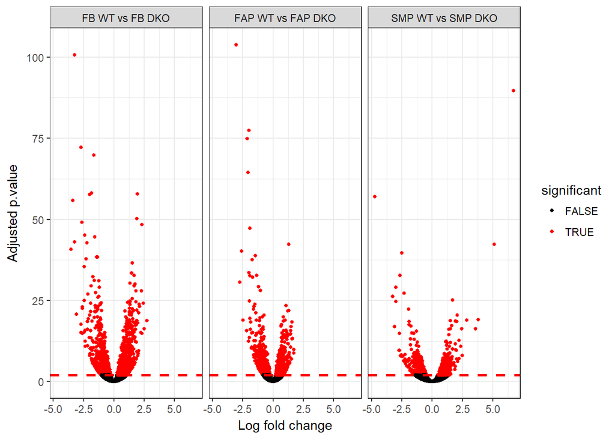

```r
threshold <- 0.01

gdata_fb <- data.frame(
  type = "FB WT vs FB DKO",
  x = res_fb$log2FoldChange,
  y = -log10(res_fb$padj),
  significant = res_fb$padj < threshold)

gdata_fap <- data.frame(
  type = "FAP WT vs FAP DKO",
  x = res_fap$log2FoldChange,
  y = -log10(res_fap$padj),
  significant = res_fap$padj < threshold)

gdata_smp <- data.frame(
  type = "SMP WT vs SMP DKO",
  x = res_smp$log2FoldChange,
  y = -log10(res_smp$padj),
  significant = res_smp$padj < threshold)


gdata <- na.omit(rbind(gdata_fb, gdata_fap, gdata_smp))

ggplot(data=gdata, aes(x=x, y=y, color=significant)) +
  facet_grid(.~type)+
  geom_point(size=1) + theme_bw()  +
  xlab("Log fold change") +
  ylab("Adjusted p.value") +
  scale_color_manual(values = c("black", "red"))+
  geom_hline(yintercept=-log10(threshold), linetype=2, size=1, colour = "Red")
```

### Venn diagram

Общие дифферениально экспрессированные гены у сравнений

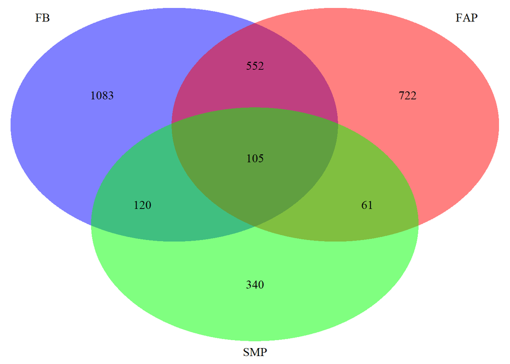

[output not shown]

```r
set_fb <- rownames(res_fb)[replace(res_fb$padj < 0.01, is.na(res_fb$padj < 0.01), F)]
set_fap <- rownames(res_fap)[replace(res_fap$padj < 0.01, is.na(res_fap$padj < 0.01), F)]
set_smp <- rownames(res_smp)[replace(res_smp$padj < 0.01, is.na(res_smp$padj < 0.01), F)]

common_fb_fap <- intersect(set_fb, set_fap)
common_fb_smp <- intersect(set_fb, set_smp)
common_fap_smp <- intersect(set_fap, set_smp)
common_all <- intersect(common_fap_smp, set_fb)

draw.triple.venn(length(set_fb), length(set_fap), length(set_smp),
                 length(common_fb_fap), length(common_fap_smp), length(common_fb_smp), length(common_all),
                 category = c("FB", "FAP", "SMP"),
                 fill = c("blue", "red", "green"), alpha = c(0.5, 0.5, 0.5), lty = "blank")
```

**Q: Можем ли мы по volcano plot предположить, транксрипционное состояние каких типов клеток изменилось сильнее/слабее после двойного нокаута?**

A: FB сильнее, SMP слабее